# Sorry, our processor is out of order

EECS 472 · Major Design Experience

Sorry, our processor  
is out of order

Designing a RISC-V core that runs instructions as soon as they’re ready

**Marco Boone**  
with Niki Lin, Shaoqian Zhou, and Sophia Chen  
Team HEADTH(e)ROB

TC 496 · University of Michigan · October 2026

## EECS 472: learn architecture by building a CPU

**The class**

EECS 472 is my Major Design Experience: a semester-long project for teams of four

**Its purpose**

Learn how fast processors work by designing, verifying, and synthesizing one in SystemVerilog

**Our project**

A 2-wide, out-of-order RISC-V core in the style of the MIPS R10000 [1] that runs real C programs

## The problem: one cache miss stalls an in-order pipeline

[figure not shown]

## The solution: execute out of order, commit in order

[figure not shown]

## Our 2-wide core: front, middle, and back end

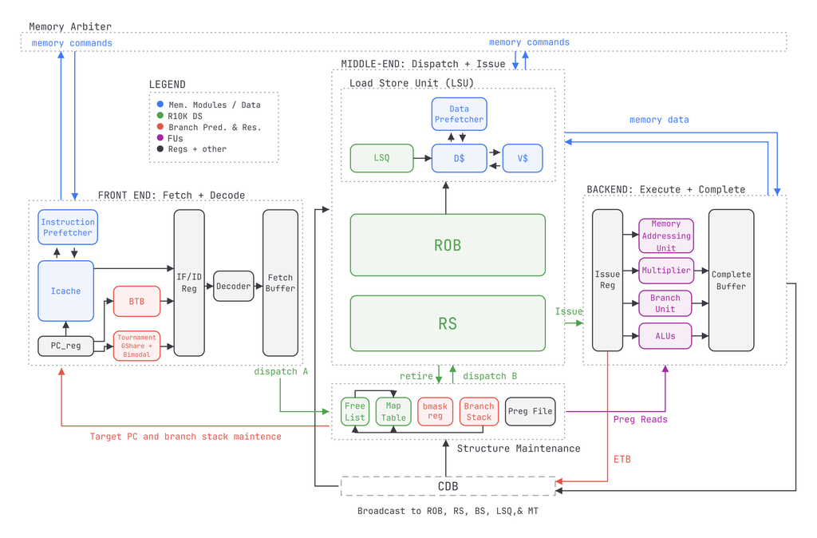

## Our method: build small, test, then integrate

[figure not shown]

## Goals: core by Oct 29, full CPU by Nov 20

[figure not shown]

## Takeaway: out of order keeps the pipeline busy

**1** Out of order inside, in order outside

**2** Small, tested pieces, then integrate

**3** Working core by Oct 29; full processor by Nov 20

## References

[1] K. C. Yeager, “The MIPS R10000 superscalar microprocessor,” *IEEE Micro*, vol. 16, no. 2, pp. 28–41, Apr. 1996.

[2] M. Boone, N. Lin, S. Zhou, and S. Chen, “Preliminary design review: an out-of-order RISC-V processor,” EECS 472, Univ. of Michigan, Oct. 2026.

[3] EECS 472 Final Project Specification, Univ. of Michigan, Fall 2026.